# Designing the Upgrades Shop

In our design, we have two game layers. We have the game world and the player’s interface. Previously, we added upgrades to the game’s world. But players are not able to interact with them yet. We need an interface that allows players to access a tower’s upgrades and buy them.

Our interface consists of a list of buttons bound to their respective upgrades. Every time the player selects a tower, a panel displaying these buttons appears. Let’s start with the buttons.

## Creating upgrade buttons

Let’s create a new scene with a *Button* as the root and name it *UIUpgradeButton*. Save it as `res://UI/UIUpgradeShop/UIUpgradeButton.tscn` and attach a script to it.

These buttons display information about an upgrade and shouldn’t be available if player doesn’t have enough gold to it. We can create a method that receives two arguments, one for the `upgrade`, and the second for the `player_gold`.

In this method, we set the button’s properties to match the upgrade’s. For its `text`, we use two placeholders and format them using the `upgrade.display_name` and `upgrade.cost`. Then, we set the button’s `tooltip` to match the `upgrade.description`.

After that, we disable the button if the `player_gold` is smaller than the `upgrade.cost`. This is how the *UIUpgradeButton* script looks like:

`UIUpgradeButton.gd`

```
class_name UIUpgradeButton
extends Button


func update_display(upgrade: Upgrade, player_gold: int) -> void:
    text = "%s: %sg" % [upgrade.display_name, upgrade.cost]
    hint_tooltip = upgrade.description
    disabled = player_gold < upgrade.cost
```

## Designing the shop’s panel

We need to provide a panel that displays the upgrade buttons.

Create a new scene with a *Control* as root and name it *UIUpgradeShop*. Save the scene as `res://UI/UIUpgradeShop/UIUpgradeShop.tscn`. Set its *Rect > Size* to `0.0` in both axes. This should prevent it from consuming players’ inputs. But to ensure that, also set its *Mouse > Filter* property to *Ignore*.

We use this root node to rotate the actual panel based on its position on the screen. We want the panel to always stay inside the screen. Though, this rotation’s pivot should match the center of the current selected tower. For that, let’s change the *Rect > Pivot Offset* value to `32.0` pixels on both axes.

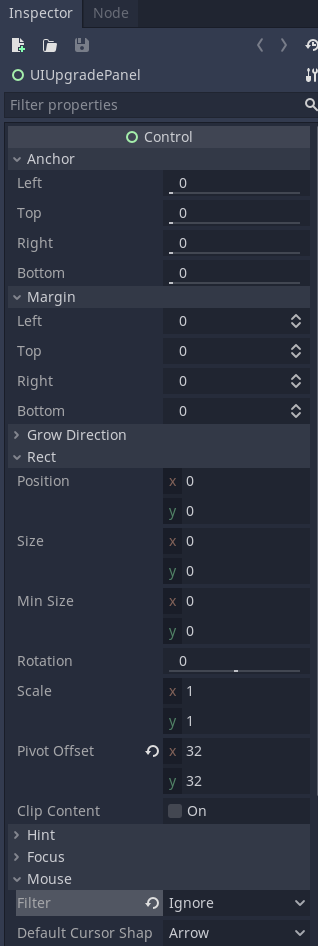

Add a *Panel* node as child of the *UIUpgradeShop*. Set *Rect > Size* to `256` in the `x` axis and `320` in the `y` axis to give us enough room to add buttons.

As we rotate the *Panel* as well, it’s important that its pivot matches its center. Set its *Rect > Pivot Offset* to `128` in the `x` axis and `160` in the `y`.

We also position the panel above the root node at `(-96, -350)`.

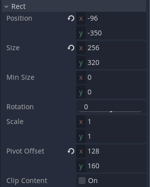

Add a *Label* as child of the *Panel*. Set both *Align* and *Valign* properties to *Center* and write *Upgrades* in the *Text* property. Center the label at the panel’s top portion. Add an *HSeparator* as child of the *Panel* to separate the label from the list of buttons.

As for the list of buttons itself, add a *VBoxContainer* as a *Panel*’s child. Note that if you decide to have *a lot* of upgrades for a single tower, you can add a *ScrollContainer* instead, and the *VBoxContainer* as its child.

Using the *Editor*, let’s design the panel’s elements so that they have a small margin away from the panel’s edge. Like this:

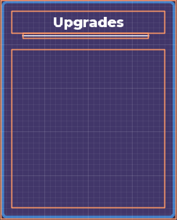

Set *Panel > Rect > Scale* to `0.0` in both axes and insert a new key at the beginning of the animation. At `0.1` seconds, change the scale to `0.05` and `1.0` respectively in the `x` and `y` axes and add a new key with this value. Finally at `0.3` seconds, change the scale to `1.0` in both axes and add yet another key.

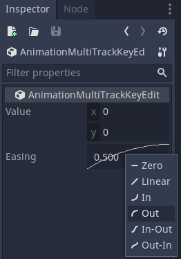

To make it disappear, duplicate this animation and rename the duplicate as *Disappear*. In this one, we swap the first and the third keys so that it does the opposite of the appear animation.

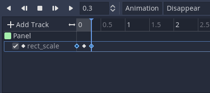

This is how it should look like when we play the animations:

[figure not shown]

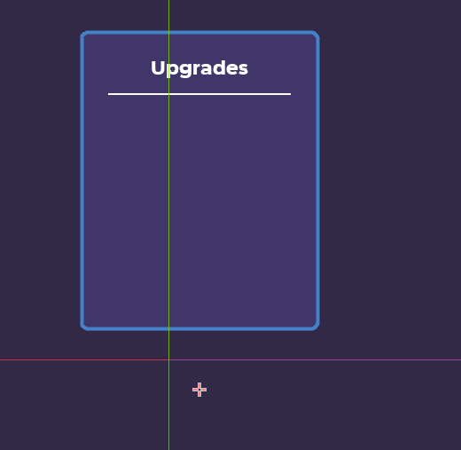

Let’s move on to the actual shop logic. In the next lesson, we’ll create the *UIUpgradeShop* behavior to allow players to buy upgrades for their towers.